# QK Box 9.2

### Standardized coefficients (usual)

```r
lm.beta.yasuhara <- lm.beta(yasuhara.lm)
lm.beta.yasuhara
```

```
Call:
lm(formula = sprich ~ cldepth + ctemp + csalinity + cprod + cprod2 +
    clseasprod + cicefree, data = yasuhara)

Standardized Coefficients::
(Intercept)     cldepth       ctemp   csalinity       cprod      cprod2  clseasprod    cicefree
         NA   0.1690832  -0.4625760   0.2826530  -0.5191710   0.1263809  -0.7765347   0.2955774
```

### standardized coefficients (both usual and partial sd)

```r
std.coef(yasuhara.lm, partial.sd=FALSE)
```

```
            Estimate* Std. Error*  df
(Intercept)   0.00000     0.00000 121
cldepth       0.16908     0.15651 121
ctemp        -0.46258     0.14122 121
csalinity     0.28265     0.16762 121
cprod        -0.51917     0.39455 121
cprod2        0.12638     0.34187 121
clseasprod   -0.77653     0.29557 121
cicefree      0.29558     0.34181 121
```

```r
std.coef(yasuhara.lm, partial.sd=TRUE)
```

```
            Estimate* Std. Error*  df
(Intercept)   0.00000     0.00000 121
cldepth       0.52569     0.48659 121
ctemp        -1.59381     0.48659 121
csalinity     0.82051     0.48659 121
cprod        -0.64028     0.48659 121
cprod2        0.17988     0.48659 121
clseasprod   -1.27840     0.48659 121
cicefree      0.42078     0.48659 121
```

## Relative importance metrics

```r
calc.relimp(yasuhara.lm, type = c("lmg", "pmvd", "last", "first", "betasq", "pratt"), rela=FALSE)
```

```
Response variable: sprich
Total response variance: 42.40007
Analysis based on 129 observations

7 Regressors:
cldepth ctemp csalinity cprod cprod2 clseasprod cicefree
Proportion of variance explained by model: 31.9%
Metrics are not normalized (rela=FALSE).

Relative importance metrics:

                  lmg        pmvd         last       first     betasq       pratt
cldepth    0.04585922 0.028074571 0.0065685629 0.068259277 0.02858913  0.04417548
ctemp      0.08247454 0.088397149 0.0603790501 0.040057552 0.21397655  0.09258173
csalinity  0.06431606 0.097053096 0.0160021617 0.101320302 0.07989271  0.08997085
cprod      0.03329101 0.047321887 0.0097444976 0.056471134 0.26953855  0.12337402
cprod2     0.02508002 0.003789243 0.0007690854 0.049404358 0.01597212 -0.02809079
clseasprod 0.04138893 0.046455138 0.0388458895 0.001220917 0.60300611 -0.02713338
cicefree   0.02662583 0.007944537 0.0042083759 0.006679892 0.08736597  0.02415772

Average coefficients for different model sizes:

                      1X           2Xs           3Xs           4Xs           5Xs           6Xs           7Xs
cldepth     3.4063617807  3.148954e+00  3.127298e+00  3.026922e+00  2.929623e+00  2.667016e+00  2.204501e+00
ctemp      -0.6187634981 -8.102006e-01 -1.206430e+00 -1.513119e+00 -1.610497e+00 -1.576792e+00 -1.430097e+00
csalinity   1.0166022108  1.060860e+00  1.097903e+00  1.146328e+00  1.080044e+00  9.772467e-01  9.027269e-01
cprod      -0.0261160393 -2.985905e-02 -3.049686e-02 -3.221847e-02 -3.832766e-02 -4.901019e-02 -5.705642e-02
cprod2     -0.0001128541 -9.316944e-05 -8.384049e-05 -7.733780e-05 -4.832558e-05  8.742253e-06  6.416765e-05
clseasprod  1.6030832095 -5.744933e+00 -1.606088e+01 -2.573282e+01 -3.230270e+01 -3.526878e+01 -3.562656e+01
cicefree    0.0115496083  6.981186e-03  1.077312e-02  2.013563e-02  3.047528e-02  3.673742e-02  4.176896e-02
```

```r
yasuhara.boot <- boot.relimp(yasuhara.lm, b=1000, type = c("lmg", "pmvd"))
booteval.relimp(yasuhara.boot)
```

```
Response variable: sprich
Total response variance: 42.40007
Analysis based on 129 observations

7 Regressors:
cldepth ctemp csalinity cprod cprod2 clseasprod cicefree
Proportion of variance explained by model: 31.9%
Metrics are not normalized (rela=FALSE).

Relative importance metrics:

                  lmg        pmvd
cldepth    0.04585922 0.028074571
ctemp      0.08247454 0.088397149
csalinity  0.06431606 0.097053096
cprod      0.03329101 0.047321887
cprod2     0.02508002 0.003789243
clseasprod 0.04138893 0.046455138
cicefree   0.02662583 0.007944537

Average coefficients for different model sizes:

                      1X           2Xs           3Xs           4Xs           5Xs           6Xs           7Xs
cldepth     3.4063617807  3.148954e+00  3.127298e+00  3.026922e+00  2.929623e+00  2.667016e+00  2.204501e+00
ctemp      -0.6187634981 -8.102006e-01 -1.206430e+00 -1.513119e+00 -1.610497e+00 -1.576792e+00 -1.430097e+00
csalinity   1.0166022108  1.060860e+00  1.097903e+00  1.146328e+00  1.080044e+00  9.772467e-01  9.027269e-01
cprod      -0.0261160393 -2.985905e-02 -3.049686e-02 -3.221847e-02 -3.832766e-02 -4.901019e-02 -5.705642e-02
cprod2     -0.0001128541 -9.316944e-05 -8.384049e-05 -7.733780e-05 -4.832558e-05  8.742253e-06  6.416765e-05
clseasprod  1.6030832095 -5.744933e+00 -1.606088e+01 -2.573282e+01 -3.230270e+01 -3.526878e+01 -3.562656e+01
cicefree    0.0115496083  6.981186e-03  1.077312e-02  2.013563e-02  3.047528e-02  3.673742e-02  4.176896e-02


 Confidence interval information ( 1000 bootstrap replicates, bty= perc ):
Relative Contributions with confidence intervals:

                                   Lower  Upper
                percentage 0.95    0.95   0.95
cldepth.lmg     0.0459     ABCDEFG 0.0154 0.1130
ctemp.lmg       0.0825     ABCDEFG 0.0241 0.1712
csalinity.lmg   0.0643     ABCDEF_ 0.0258 0.1247
```

[output cut: 53 more lines]

```
ctemp-clseasprod.pmvd      0.0419         -0.0545  0.1278
ctemp-cicefree.pmvd        0.0805         -0.0380  0.1564
csalinity-cprod.pmvd       0.0497         -0.1081  0.1712
csalinity-cprod2.pmvd      0.0933         -0.0686  0.1912
csalinity-clseasprod.pmvd  0.0506         -0.0586  0.1530
csalinity-cicefree.pmvd    0.0891         -0.0367  0.1894
cprod-cprod2.pmvd          0.0435         -0.0874  0.1276
cprod-clseasprod.pmvd      0.0009         -0.0643  0.0829
cprod-cicefree.pmvd        0.0394         -0.0368  0.1235
cprod2-clseasprod.pmvd    -0.0427         -0.0833  0.0476
cprod2-cicefree.pmvd      -0.0042         -0.0495  0.0857
clseasprod-cicefree.pmvd   0.0385         -0.0272  0.0843

* indicates that CI for difference does not include 0.
CAUTION: Bootstrap confidence intervals can be somewhat liberal.
```

### Compare to uncentered predictors - no change in conclusions

```r
yasuhara.lm1 <- lm(sprich~ldepth+temp+salinity+prod+lseasprod+icefree, data=yasuhara)
vif(lm(sprich~ldepth+temp+salinity+prod+lseasprod+icefree, data=yasuhara))
```

```
   ldepth      temp  salinity      prod lseasprod   icefree
 4.187101  3.451081  4.989499  2.979970 12.260591 19.008007
```

```r
summary(yasuhara.lm1)
```

```
Call:
lm(formula = sprich ~ ldepth + temp + salinity + prod + lseasprod +
    icefree, data = yasuhara)

Residuals:
    Min      1Q  Median      3Q     Max
-9.2653 -4.1493 -0.6728  3.4358 21.5077

Coefficients:
             Estimate Std. Error t value Pr(>|t|)
(Intercept) -12.37608   20.03901  -0.618 0.537990
ldepth        2.35151    1.99432   1.179 0.240650
temp         -1.45622    0.42933  -3.392 0.000936 ***
salinity      0.90767    0.53328   1.702 0.091293 .
prod         -0.04192    0.01418  -2.956 0.003747 **
lseasprod   -33.32844   12.00870  -2.775 0.006383 **
icefree       0.03658    0.04606   0.794 0.428562
---
Signif. codes:  0 ‘***’ 0.001 ‘**’ 0.01 ‘*’ 0.05 ‘.’ 0.1 ‘ ’ 1

Residual standard error: 5.507 on 122 degrees of freedom
Multiple R-squared:  0.3183,    Adjusted R-squared:  0.2847
F-statistic: 9.493 on 6 and 122 DF,  p-value: 1.502e-08
```

```r
calc.relimp(yasuhara.lm, type = c("lmg", "pmvd", "last", "first", "betasq", "pratt"), rela=FALSE)
```

```
Response variable: sprich
Total response variance: 42.40007
Analysis based on 129 observations

7 Regressors:
cldepth ctemp csalinity cprod cprod2 clseasprod cicefree
Proportion of variance explained by model: 31.9%
Metrics are not normalized (rela=FALSE).

Relative importance metrics:

                  lmg        pmvd         last       first     betasq       pratt
cldepth    0.04585922 0.028074571 0.0065685629 0.068259277 0.02858913  0.04417548
ctemp      0.08247454 0.088397149 0.0603790501 0.040057552 0.21397655  0.09258173
csalinity  0.06431606 0.097053096 0.0160021617 0.101320302 0.07989271  0.08997085
cprod      0.03329101 0.047321887 0.0097444976 0.056471134 0.26953855  0.12337402
cprod2     0.02508002 0.003789243 0.0007690854 0.049404358 0.01597212 -0.02809079
clseasprod 0.04138893 0.046455138 0.0388458895 0.001220917 0.60300611 -0.02713338
cicefree   0.02662583 0.007944537 0.0042083759 0.006679892 0.08736597  0.02415772

Average coefficients for different model sizes:

                      1X           2Xs           3Xs           4Xs           5Xs           6Xs           7Xs
cldepth     3.4063617807  3.148954e+00  3.127298e+00  3.026922e+00  2.929623e+00  2.667016e+00  2.204501e+00
ctemp      -0.6187634981 -8.102006e-01 -1.206430e+00 -1.513119e+00 -1.610497e+00 -1.576792e+00 -1.430097e+00
csalinity   1.0166022108  1.060860e+00  1.097903e+00  1.146328e+00  1.080044e+00  9.772467e-01  9.027269e-01
cprod      -0.0261160393 -2.985905e-02 -3.049686e-02 -3.221847e-02 -3.832766e-02 -4.901019e-02 -5.705642e-02
cprod2     -0.0001128541 -9.316944e-05 -8.384049e-05 -7.733780e-05 -4.832558e-05  8.742253e-06  6.416765e-05
clseasprod  1.6030832095 -5.744933e+00 -1.606088e+01 -2.573282e+01 -3.230270e+01 -3.526878e+01 -3.562656e+01
cicefree    0.0115496083  6.981186e-03  1.077312e-02  2.013563e-02  3.047528e-02  3.673742e-02  4.176896e-02
```

## Now hierarchical partitioning

This step uses the subsets of the original dataframe into response and predictors.

```r
yasuhara_sprich<-yasuhara$sprich
yasuhara_pred<-subset(yasuhara, select = c("cldepth","ctemp","csalinity","clseasprod","cicefree","cprod", "cprod2"))
hier.part(yasuhara_sprich, yasuhara_pred, family="gaussian", gof="Rsqu")
```

```
Error in hier.part(yasuhara_sprich, yasuhara_pred, family = "gaussian",  :
  could not find function "hier.part"
```

The package hier.part was removed from CRAN in March 2023. The code above will work if you have hier.part installed already. An alternative is to use the package *glmm.hp*, which is done in the next code chunk.

Hier.part can also be installed from Github, though there may be issues with M1/M2 Macs. The quick way from Github is using devtools: devtools::install_github(“cjbwalsh/hier.part”)

```r
library (glmm.hp)
glmm.hp(yasuhara.lm, type="R2")
```

```
$Total.R2
[1] 0.3190356

$hierarchical.partitioning
           Unique Average.share Individual I.perc(%)
cldepth    0.0066        0.0393     0.0459     14.38
ctemp      0.0604        0.0221     0.0825     25.85
csalinity  0.0160        0.0483     0.0643     20.15
cprod      0.0097        0.0236     0.0333     10.44
cprod2     0.0008        0.0243     0.0251      7.87
clseasprod 0.0388        0.0026     0.0414     12.97
cicefree   0.0042        0.0224     0.0266      8.34

$variables
[1] "cldepth"    "ctemp"      "csalinity"  "cprod"      "cprod2"     "clseasprod" "cicefree"

$type
[1] "hierarchical.partitioning"

attr(,"class")
[1] "glmmhp"
```

## Model selection

```r
options(na.action = "na.fail")
yasuhara.dredge <-dredge(yasuhara.lm, beta="none", evaluate=TRUE)
```

```
Fixed term is "(Intercept)"
```

```r
yasuhara.dredge
```

```
Global model call: lm(formula = sprich ~ cldepth + ctemp + csalinity + cprod + cprod2 +
    clseasprod + cicefree, data = yasuhara)
---
Model selection table
    (Intrc)     cicfr   cldpt    clssp     cprod      cprd2  cslnt   ctemp df   logLik  AICc delta weight
109    14.3                   -24.4200 -0.039950            1.3250 -1.6650  6 -400.517 813.7  0.00  0.175
111    14.3            2.2380 -25.0200 -0.044560            0.8302 -1.6970  7 -399.854 814.6  0.91  0.111
79     14.3            4.8830 -25.9700 -0.054010                   -1.6350  6 -401.159 815.0  1.29  0.092
117    14.3                   -20.2300           -1.403e-04 1.4800 -1.6320  6 -401.306 815.3  1.58  0.079
110    14.3  0.032700         -31.8200 -0.037380            1.4170 -1.4480  7 -400.252 815.4  1.71  0.074
125    14.3                   -25.4600 -0.054120  5.737e-05 1.2790 -1.6740  7 -400.451 815.8  2.11  0.061
119    14.3            2.4260 -20.6300           -1.625e-04 0.9571 -1.6640  7 -400.562 816.0  2.33  0.055
112    14.3  0.036580  2.3520 -33.3300 -0.041920            0.9077 -1.4560  8 -399.521 816.2  2.52  0.050
127    14.3            2.1860 -25.3800 -0.049530  2.056e-05 0.8251 -1.6990  8 -399.846 816.9  3.17  0.036
80     14.3  0.022240  5.1010 -31.0800 -0.052940                   -1.4860  7 -401.035 817.0  3.27  0.034
```

[output cut: 68 more lines]

above results match table 1 in paper

## Model averaging

```r
yasuhara.ma<-model.avg(yasuhara.dredge)
summary(yasuhara.ma)
```

```
Call:
model.avg(object = yasuhara.dredge)

Component model call:
lm(formula = sprich ~ <128 unique rhs>, data = yasuhara)

Component models:
        df  logLik   AICc delta weight
3467     6 -400.52 813.72  0.00   0.17
23467    7 -399.85 814.63  0.91   0.11
2347     6 -401.16 815.01  1.29   0.09
3567     6 -401.31 815.30  1.58   0.08
13467    7 -400.25 815.43  1.71   0.07
34567    7 -400.45 815.83  2.11   0.06
23567    7 -400.56 816.05  2.33   0.05
```

[output cut: 150 more lines]

```r
confint(yasuhara.ma)
```

```
                    2.5 %        97.5 %
(Intercept)  1.333804e+01 15.2666114702
clseasprod  -4.496777e+01 -7.4179250862
cprod       -9.849705e-02  0.0046952091
csalinity    2.503839e-01  2.1330064474
ctemp       -2.339799e+00 -0.8774189158
cldepth     -9.089778e-01  7.7378031678
cprod2      -3.783339e-04  0.0002500826
cicefree    -9.064154e-02  0.1350423590
```

### Get standardized model averaged estimates

```r
yasuhara.ma1<-model.avg(yasuhara.dredge, beta="sd")  #Code not running at moment
```

```
Error in h(simpleError(msg, call)) :
  error in evaluating the argument 'x' in selecting a method for function 't': incorrect number of dimensions
```

```r
summary(yasuhara.ma1)
```

```
Error in h(simpleError(msg, call)) :
  error in evaluating the argument 'object' in selecting a method for function 'summary': object 'yasuhara.ma1' not found
```

```r
confint(yasuhara.ma1)
```

```
Error: object 'yasuhara.ma1' not found
```

```r
yasuhara.ma2<-model.avg(yasuhara.dredge, beta="partial.sd")
summary(yasuhara.ma2)
```

```
Call:
model.avg(object = get.models(object = yasuhara.dredge, subset = NA),
    beta = "partial.sd")

Component model call:
lm(formula = sprich ~ <128 unique rhs>, data = yasuhara)

Component models:
        df  logLik   AICc delta weight
3467     6 -400.52 813.72  0.00   0.17
23467    7 -399.85 814.63  0.91   0.11
2347     6 -401.16 815.01  1.29   0.09
3567     6 -401.31 815.30  1.58   0.08
13467    7 -400.25 815.43  1.71   0.07
34567    7 -400.45 815.83  2.11   0.06
```

[output cut: 151 more lines]

```r
confint(yasuhara.ma2)
```

```
                  2.5 %       97.5 %
(Intercept)  0.00000000  0.000000000
clseasprod  -2.96240884 -0.577283501
cprod       -2.71499484  0.003028486
csalinity   -0.01817383  3.462099467
ctemp       -3.68091309 -1.031230881
cldepth     -0.63405782  3.080315443
cprod2      -2.60548788  1.128768004
cicefree    -1.45824644  1.743001809
```

### Sum of akaike weights

```r
sw(yasuhara.dredge)
```

```
                     ctemp clseasprod csalinity cprod cldepth cprod2 cicefree
Sum of weights:      1.00  0.96       0.78      0.74  0.52    0.43   0.32
N containing models:   64    64         64        64    64      64     64
```

```r
#importance(yasuhara.dredge)   #importance is Decunct
```

## Redo analysis by reducing collinearity

**- omit prod squared and ice-free days**

```r
vif(lm(sprich~cldepth+ctemp+csalinity+cprod+clseasprod, data=yasuhara))
```

```
   cldepth      ctemp  csalinity      cprod clseasprod
  4.165738   1.731734   4.822565   2.816215   2.954188
```

```r
cor(yasuhara[,c('cldepth','ctemp','csalinity','cprod','clseasprod')])
```

```
               cldepth      ctemp   csalinity       cprod  clseasprod
cldepth     1.00000000  0.3891785  0.84784714 -0.09488397 -0.08130645
ctemp       0.38917848  1.0000000  0.34629660  0.22755053 -0.52110033
csalinity   0.84784714  0.3462966  1.00000000 -0.32989442  0.05660052
cprod      -0.09488397  0.2275505 -0.32989442  1.00000000 -0.72386615
clseasprod -0.08130645 -0.5211003  0.05660052 -0.72386615  1.00000000
```

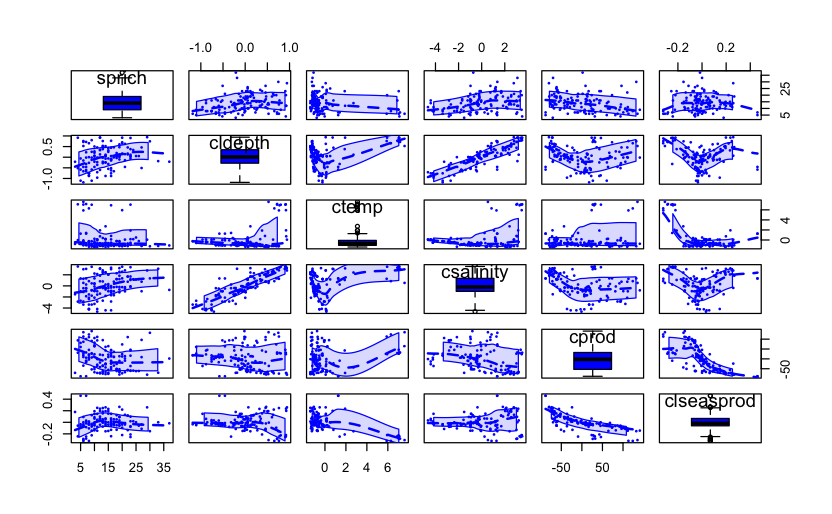

```r
scatterplotMatrix(~sprich+cldepth+ctemp+csalinity+cprod+clseasprod, data=yasuhara, cex=0.25, regLine=FALSE, diagonal=list(method='boxplot'))
```

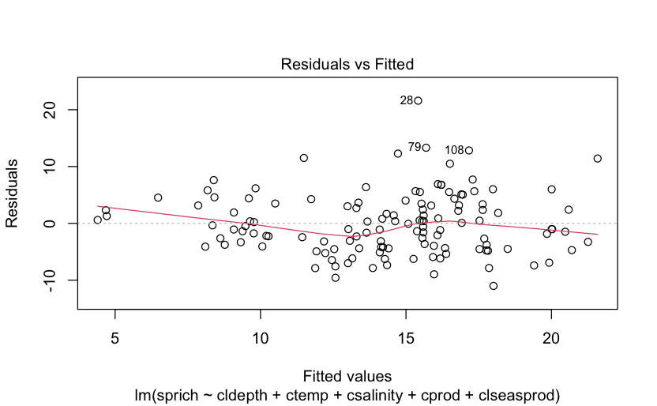

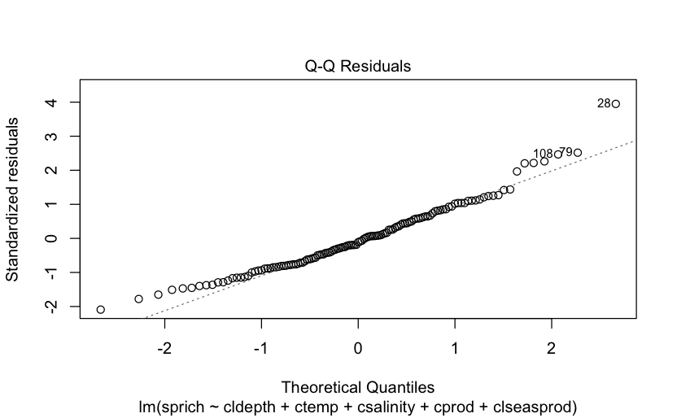

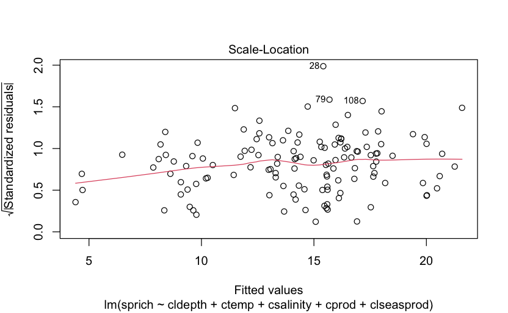

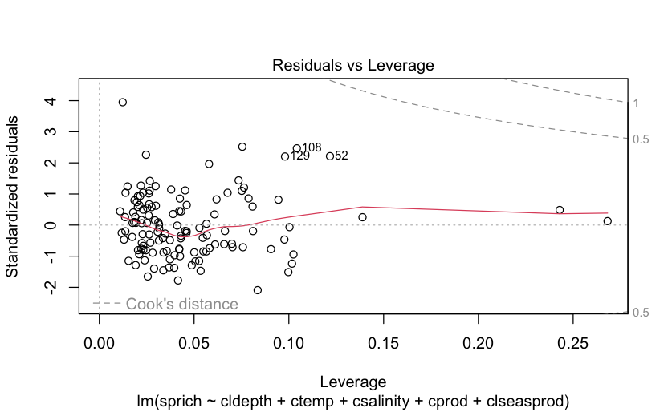

```r
yasuhara.lm1 <- lm(sprich~cldepth+ctemp+csalinity+cprod+clseasprod, data=yasuhara)
plot(yasuhara.lm1)
```

```r
influence.measures(yasuhara.lm1)
```

```
Influence measures of
     lm(formula = sprich ~ cldepth + ctemp + csalinity + cprod + clseasprod,      data = yasuhara) :
```

|  | dfb.1_ | dfb.cldp | dfb.ctmp | dfb.csln | dfb.cprd | dfb.clss | dffit | cov.r | cook.d | hat | inf |
| --- | --- | --- | --- | --- | --- | --- | --- | --- | --- | --- | --- |
| 1 | -0.033818649 | -0.0266855381 | 1.293956e-02 | 0.0279050143 | 0.0310908020 | 2.078050e-02 | -0.050605777 | 1.0611619 | 4.298119e-04 | 0.01735793 |  |
| 2 | -0.059523821 | -0.0673430836 | 9.379590e-03 | 0.0690440040 | 0.0581125053 | 1.697636e-02 | -0.102807156 | 1.0517524 | 1.769515e-03 | 0.02312466 |  |
| 3 | 0.075028823 | 0.0429695808 | 8.492065e-02 | -0.0431074531 | 0.0900877187 | 1.847890e-01 | 0.211900892 | 1.0826315 | 7.503107e-03 | 0.06183290 |  |
| 4 | -0.009739640 | -0.0118374895 | -1.142738e-03 | 0.0112879597 | 0.0092873950 | -1.850617e-03 | -0.019659804 | 1.0838199 | 6.493969e-05 | 0.03158514 |  |
| 5 | 0.113286860 | 0.0804889399 | -2.399539e-02 | -0.0923696324 | -0.1225334697 | -3.638127e-02 | 0.190602930 | 0.9920882 | 6.024582e-03 | 0.02194373 |  |
| 6 | -0.067794003 | -0.0589647970 | -9.377034e-03 | 0.0769915292 | 0.0585105753 | 1.807928e-03 | -0.114597624 | 1.0438691 | 2.196273e-03 | 0.02215027 |  |
| 7 | -0.148367404 | -0.2120693862 | 6.846340e-02 | 0.1910365537 | 0.1112729852 | 6.518933e-02 | -0.269288793 | 0.9420281 | 1.191489e-02 | 0.02553700 |  |
| 8 | 0.008631029 | 0.0070599263 | -1.107064e-03 | -0.0077407489 | -0.0076229563 | -2.218195e-03 | 0.013293391 | 1.0693768 | 2.969149e-05 | 0.01838894 |  |
| 9 | -0.050372756 | -0.0409194607 | -2.283318e-02 | 0.0563271279 | 0.0312778428 | -2.534921e-02 | -0.093839182 | 1.0624802 | 1.475809e-03 | 0.02690217 |  |
| 10 | -0.037548856 | 0.0053179890 | -1.742230e-02 | 0.0318124137 | 0.0172120215 | 8.696789e-03 | -0.078141839 | 1.0773352 | 1.024557e-03 | 0.03357253 |  |

[output cut: 119 more lines]

```r
summary(yasuhara.lm1)
```

```
Call:
lm(formula = sprich ~ cldepth + ctemp + csalinity + cprod + clseasprod,
    data = yasuhara)

Residuals:
     Min       1Q   Median       3Q      Max
-11.0085  -4.1007  -0.5914   3.3649  21.5832

Coefficients:
             Estimate Std. Error t value Pr(>|t|)
(Intercept)  14.30233    0.48414  29.542  < 2e-16 ***
cldepth       2.23836    1.98624   1.127  0.26196
ctemp        -1.69692    0.30367  -5.588 1.40e-07 ***
csalinity     0.83020    0.52350   1.586  0.11534
cprod        -0.04456    0.01377  -3.237  0.00155 **
clseasprod  -25.01814    5.88582  -4.251 4.18e-05 ***
---
Signif. codes:  0 ‘***’ 0.001 ‘**’ 0.01 ‘*’ 0.05 ‘.’ 0.1 ‘ ’ 1

Residual standard error: 5.499 on 123 degrees of freedom
Multiple R-squared:  0.3147,    Adjusted R-squared:  0.2869
F-statistic:  11.3 on 5 and 123 DF,  p-value: 5.588e-09
```

```r
confint(yasuhara.lm1)
```

```
                   2.5 %       97.5 %
(Intercept)  13.34400613  15.26064504
cldepth      -1.69326657   6.16999552
ctemp        -2.29800759  -1.09582645
csalinity    -0.20604108   1.86643110
cprod        -0.07180444  -0.01730728
clseasprod  -36.66875900 -13.36752083
```

```r
std.coef(yasuhara.lm1, partial.sd=FALSE)
```

```
            Estimate* Std. Error*  df
(Intercept)  0.000000    0.000000 123
cldepth      0.171680    0.152342 123
ctemp       -0.548881    0.098223 123
csalinity    0.259943    0.163913 123
cprod       -0.405425    0.125259 123
clseasprod  -0.545308    0.128290 123
```

```r
std.coef(yasuhara.lm1, partial.sd=TRUE)
```

```
            Estimate* Std. Error*  df
(Intercept)   0.00000     0.00000 123
cldepth       0.54559     0.48414 123
ctemp        -2.70540     0.48414 123
csalinity     0.76777     0.48414 123
cprod        -1.56701     0.48414 123
clseasprod   -2.05786     0.48414 123
```

```r
calc.relimp(yasuhara.lm1, type = c("lmg", "pmvd", "last", "first", "betasq", "pratt"), rela=FALSE)
```

```
Response variable: sprich
Total response variance: 42.40007
Analysis based on 129 observations

5 Regressors:
cldepth ctemp csalinity cprod clseasprod
Proportion of variance explained by model: 31.47%
Metrics are not normalized (rela=FALSE).

Relative importance metrics:

                  lmg       pmvd        last       first     betasq       pratt
cldepth    0.04438295 0.02835060 0.007075381 0.068259277 0.02947418  0.04485406
ctemp      0.10760292 0.09052456 0.173970310 0.040057552 0.30127025  0.10985512
csalinity  0.06734447 0.09635017 0.014011240 0.101320302 0.06757011  0.08274191
cprod      0.05206685 0.05101218 0.058365425 0.056471134 0.16436960  0.09634385
clseasprod 0.04334380 0.04850348 0.100657416 0.001220917 0.29736096 -0.01905395

Average coefficients for different model sizes:

                    1X         2Xs          3Xs          4Xs          5Xs
cldepth     3.40636178  2.85470055   2.49515403   1.97259292   2.23836447
ctemp      -0.61876350 -0.85958909  -1.21281836  -1.49335017  -1.69691702
csalinity   1.01660221  1.09488127   1.10369224   1.10082495   0.83019501
cprod      -0.02611604 -0.02781194  -0.02855918  -0.03358681  -0.04455586
clseasprod  1.60308321 -3.55138802 -10.68948683 -17.90736403 -25.01813992
```

```r
yasuhara.boot1 <- boot.relimp(yasuhara.lm1, b=1000, type = c("lmg", "pmvd"))
booteval.relimp(yasuhara.boot1)
```

```
Response variable: sprich
Total response variance: 42.40007
Analysis based on 129 observations

5 Regressors:
cldepth ctemp csalinity cprod clseasprod
Proportion of variance explained by model: 31.47%
Metrics are not normalized (rela=FALSE).

Relative importance metrics:

                  lmg       pmvd
cldepth    0.04438295 0.02835060
ctemp      0.10760292 0.09052456
csalinity  0.06734447 0.09635017
cprod      0.05206685 0.05101218
clseasprod 0.04334380 0.04850348

Average coefficients for different model sizes:

                    1X         2Xs          3Xs          4Xs          5Xs
cldepth     3.40636178  2.85470055   2.49515403   1.97259292   2.23836447
ctemp      -0.61876350 -0.85958909  -1.21281836  -1.49335017  -1.69691702
csalinity   1.01660221  1.09488127   1.10369224   1.10082495   0.83019501
cprod      -0.02611604 -0.02781194  -0.02855918  -0.03358681  -0.04455586
clseasprod  1.60308321 -3.55138802 -10.68948683 -17.90736403 -25.01813992


 Confidence interval information ( 1000 bootstrap replicates, bty= perc ):
Relative Contributions with confidence intervals:

                                 Lower  Upper
                percentage 0.95  0.95   0.95
cldepth.lmg     0.0444     ABCDE 0.0150 0.1103
ctemp.lmg       0.1076     ABCDE 0.0312 0.2066
csalinity.lmg   0.0673     ABCDE 0.0269 0.1363
cprod.lmg       0.0521     ABCDE 0.0117 0.1425
clseasprod.lmg  0.0433     _BCDE 0.0213 0.0977

cldepth.pmvd    0.0284     ABCDE 0.0001 0.1705
```

[output cut: 23 more lines]

```
cprod-clseasprod.lmg       0.0087         -0.0522  0.0860

cldepth-ctemp.pmvd        -0.0622         -0.1546  0.1053
cldepth-csalinity.pmvd    -0.0680         -0.1897  0.1646
cldepth-cprod.pmvd        -0.0227         -0.1406  0.1282
cldepth-clseasprod.pmvd   -0.0202         -0.0910  0.1302
ctemp-csalinity.pmvd      -0.0058         -0.1223  0.1208
ctemp-cprod.pmvd           0.0395         -0.0906  0.1334
ctemp-clseasprod.pmvd      0.0420         -0.0274  0.1197
csalinity-cprod.pmvd       0.0453         -0.1329  0.1736
csalinity-clseasprod.pmvd  0.0478         -0.0648  0.1558
cprod-clseasprod.pmvd      0.0025         -0.0461  0.0892

* indicates that CI for difference does not include 0.
CAUTION: Bootstrap confidence intervals can be somewhat liberal.
```

```r
options(na.action = "na.fail")
yasuhara.dredge1 <-dredge(yasuhara.lm1, beta="none", evaluate=TRUE)
```

```
Fixed term is "(Intercept)"
```

```r
yasuhara.dredge1
```

```
Global model call: lm(formula = sprich ~ cldepth + ctemp + csalinity + cprod + clseasprod,
    data = yasuhara)
---
Model selection table
   (Intrc)   cldpt    clssp     cprod  cslnt   ctemp df   logLik  AICc delta weight
31    14.3         -24.4200 -0.039950 1.3250 -1.6650  6 -400.517 813.7  0.00  0.454
32    14.3  2.2380 -25.0200 -0.044560 0.8302 -1.6970  7 -399.854 814.6  0.91  0.288
24    14.3  4.8830 -25.9700 -0.054010        -1.6350  6 -401.159 815.0  1.29  0.239
27    14.3         -12.0000           1.6320 -1.5870  5 -405.141 820.8  7.05  0.013
28    14.3  0.3288 -11.8700           1.5640 -1.5900  6 -405.126 822.9  9.22  0.005
25    14.3                            1.4070 -1.0900  4 -408.965 826.3 12.53  0.001
26    14.3  1.2080                    1.1670 -1.1210  5 -408.774 828.0 14.31  0.000
29    14.3                  -0.001752 1.3830 -1.0710  5 -408.949 828.4 14.66  0.000
30    14.3  1.4790          -0.004179 1.0570 -1.0830  6 -408.694 830.1 16.35  0.000
20    14.3  5.5210  -7.6080                  -1.3950  5 -410.228 830.9 17.22  0.000
```

[output cut: 23 more lines]

```r
sw(yasuhara.dredge1)
```

```
                     ctemp clseasprod cprod csalinity cldepth
Sum of weights:      1.00  1.00       0.98  0.76      0.53
N containing models:   16    16         16    16        16
```

```r
#importance(yasuhara.dredge1)
yasuhara.ma3<-model.avg(yasuhara.dredge1, beta="sd")
```

```
Error in h(simpleError(msg, call)) :
  error in evaluating the argument 'x' in selecting a method for function 't': incorrect number of dimensions
```

```r
summary(yasuhara.ma3)
```

```
Error in h(simpleError(msg, call)) :
  error in evaluating the argument 'object' in selecting a method for function 'summary': object 'yasuhara.ma3' not found
```

```r
confint(yasuhara.ma3)
```

```
Error: object 'yasuhara.ma3' not found
```

```r
yasuhara.ma4<-model.avg(yasuhara.dredge1, beta="partial.sd")
summary(yasuhara.ma4)
```

```
Call:
model.avg(object = get.models(object = yasuhara.dredge1, subset = NA),
    beta = "partial.sd")

Component model call:
lm(formula = sprich ~ <32 unique rhs>, data = yasuhara)

Component models:
       df  logLik   AICc delta weight
2345    6 -400.52 813.72  0.00   0.45
12345   7 -399.85 814.63  0.91   0.29
1235    6 -401.16 815.01  1.29   0.24
245     5 -405.14 820.77  7.05   0.01
1245    6 -405.13 822.94  9.22   0.00
45      4 -408.96 826.25 12.53   0.00
145     5 -408.77 828.04 14.31   0.00
345     5 -408.95 828.39 14.66   0.00
1345    6 -408.69 830.08 16.35   0.00
125     5 -410.23 830.94 17.22   0.00
135     5 -410.55 831.59 17.87   0.00
15      4 -411.78 831.87 18.15   0.00
235     5 -410.90 832.29 18.57   0.00
234     5 -414.60 839.69 25.97   0.00
123     5 -414.77 840.03 26.31   0.00
34      4 -415.91 840.14 26.42   0.00
4       3 -417.34 840.88 27.15   0.00
13      4 -416.43 841.18 27.46   0.00
1234    6 -414.45 841.58 27.86   0.00
134     5 -415.80 842.09 28.37   0.00
24      4 -417.32 842.97 29.24   0.00
14      4 -417.32 842.97 29.25   0.00
23      4 -417.73 843.78 30.05   0.00
124     5 -417.31 845.11 31.39   0.00
1       3 -419.67 845.54 31.81   0.00
35      4 -418.93 846.17 32.45   0.00
3       3 -420.48 847.16 33.44   0.00
12      4 -419.45 847.23 33.50   0.00
5       3 -421.60 849.38 35.66   0.00
25      4 -421.15 850.62 36.90   0.00
(Null)  2 -424.23 852.56 38.84   0.00
```

[output cut: 11 more lines]

```
cprod        -1.6217     0.5915      0.5954   2.724  0.00645 **
csalinity     1.2954     1.0576      1.0593   1.223  0.22138
ctemp        -2.6654     0.4872      0.4920   5.418 1.00e-07 ***
cldepth       0.6806     0.9453      0.9467   0.719  0.47217

(conditional average)
            Estimate Std. Error Adjusted SE z value Pr(>|z|)
(Intercept)   0.0000     0.0000      0.0000     NaN      NaN
clseasprod   -2.0483     0.4967      0.5014   4.085  4.4e-05 ***
cprod        -1.6536     0.5514      0.5557   2.976  0.00292 **
csalinity     1.7019     0.8819      0.8845   1.924  0.05434 .
ctemp        -2.6654     0.4871      0.4919   5.418  6.0e-08 ***
cldepth       1.2805     0.9556      0.9581   1.337  0.18136
---
Signif. codes:  0 ‘***’ 0.001 ‘**’ 0.01 ‘*’ 0.05 ‘.’ 0.1 ‘ ’ 1
```

```r
confint(yasuhara.ma4)
```

```
                  2.5 %     97.5 %
(Intercept)  0.00000000  0.0000000
clseasprod  -3.03090465 -1.0656097
cprod       -2.74267932 -0.5644916
csalinity   -0.03169398  3.4354804
ctemp       -3.62951109 -1.7012384
cldepth     -0.59724609  3.1582464
```